# Metodo Lineal Multivariable

```r
library(tidyverse) # metapackage of all tidyverse packages
library(dplyr)
library(ggplot2)
```

```r
clientes <-read_csv("D:/d/2-ESTUDIO/R/LIbro Power bi R Python/seccion 2/Seccion II R/clientes.csv")
```

```
Warning messages:
1: In readChar(file, size, TRUE) : truncating string with embedded nuls
2: In readChar(file, size, TRUE) : truncating string with embedded nuls
```

```r
data(clientes)
```

[output not shown]

```r
head(clientes) # visualizamos los valores
```

| edad | ingreso | gasto | ahorros |
| --- | --- | --- | --- |
| 58 | 77769 | 0.7913288 | 6559.830 |
| 59 | 81799 | 0.7910820 | 5417.661 |
| 62 | 74751 | 0.7026570 | 9258.993 |
| 59 | 74373 | 0.7656796 | 7346.335 |
| 87 | 17760 | 0.3487775 | 16869.507 |
| 29 | 131578 | 0.8470341 | 3535.514 |

```r
NA
```

```r
str ( clientes ) # detalle de las variables
```

```
spec_tbl_df [505 x 4] (S3: spec_tbl_df/tbl_df/tbl/data.frame)
 $ edad   : num [1:505] 58 59 62 59 87 29 54 87 83 84 ...
 $ ingreso: num [1:505] 77769 81799 74751 74373 17760 ...
 $ gasto  : num [1:505] 0.791 0.791 0.703 0.766 0.349 ...
 $ ahorros: num [1:505] 6560 5418 9259 7346 16870 ...
 - attr(*, "spec")=
  .. cols(
  ..   edad = col_double(),
  ..   ingreso = col_double(),
  ..   gasto = col_double(),
  ..   ahorros = col_double()
  .. )
 - attr(*, "problems")=<externalptr>
```

1.Analizar la relación entre variables

El primer paso a la hora de establecer un modelo lineal múltiple es estudiar la relación que existe entre variables. Esta información es crítica a la hora de identificar cuáles pueden ser los mejores predictores para el modelo, qué variables presentan relaciones de tipo no lineal (por lo que no pueden ser incluidas) y para identificar colinialidad entre predictores. A modo complementario, es recomendable representar la distribución de cada variable mediante histogramas.

Las dos formas principales de hacerlo son mediante representaciones gráficas (gráficos de dispersión) y el cálculo del coeficiente de correlación de cada par de variables.

```r
round(cor(x = clientes, method = "pearson"), 3)
```

```
          edad ingreso  gasto ahorros
edad     1.000  -0.828 -0.329   0.412
ingreso -0.828   1.000  0.196  -0.411
gasto   -0.329   0.196  1.000  -0.915
ahorros  0.412  -0.411 -0.915   1.000
```

[figure not shown]

```r
library(psych)
multi.hist(x = clientes, dcol = c("blue", "red"), dlty = c("dotted", "solid"),
           main = "")
```

```r
NA
NA
```

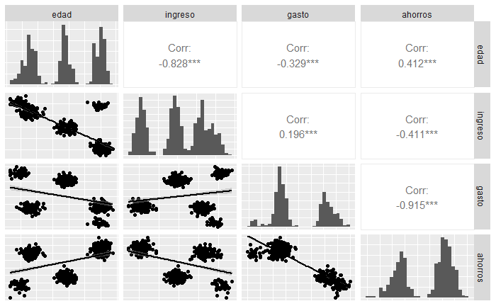

```r
library(GGally)
ggpairs(clientes, lower = list(continuous = "smooth"),
        diag = list(continuous = "barDiag"), axisLabels = "none")
```

```r
NA
NA
```

2.Generar el modelo

```r
modelo <- lm(edad ~ ingreso + gasto + ahorros , data = clientes )
summary(modelo)
```

```
Call:
lm(formula = edad ~ ingreso + gasto + ahorros, data = clientes)

Residuals:
    Min      1Q  Median      3Q     Max
-34.885  -6.743  -0.253   5.290  43.440

Coefficients:
              Estimate Std. Error t value Pr(>|t|)
(Intercept)  1.830e+02  7.503e+00   24.39   <2e-16 ***
ingreso     -6.429e-04  1.829e-05  -35.16   <2e-16 ***
gasto       -7.121e+01  5.741e+00  -12.40   <2e-16 ***
ahorros     -3.329e-03  3.239e-04  -10.28   <2e-16 ***
---
Signif. codes:  0 ‘***’ 0.001 ‘**’ 0.01 ‘*’ 0.05 ‘.’ 0.1 ‘ ’ 1

Residual standard error: 11.74 on 501 degrees of freedom
Multiple R-squared:  0.7648,    Adjusted R-squared:  0.7634
F-statistic: 543.1 on 3 and 501 DF,  p-value: < 2.2e-16
```

```r
clientes$edadpredic <- predict(modelo,newdata = clientes)
clientes
```

| edad | ingreso | gasto | ahorros | edadpredic |
| --- | --- | --- | --- | --- |
| 58 | 77769 | 0.79132878 | 6559.8299 | 54.838393 |
| 59 | 81799 | 0.79108205 | 5417.6614 | 56.067016 |
| 62 | 74751 | 0.70265695 | 9258.9930 | 54.107767 |
| 59 | 74373 | 0.76567956 | 7346.3345 | 56.230048 |
| 87 | 17760 | 0.34877755 | 16869.5071 | 90.613506 |
| 29 | 131578 | 0.84703410 | 3535.5144 | 26.343804 |
| 54 | 76500 | 0.78519785 | 6878.8842 | 55.028762 |
| 87 | 42592 | 0.35528968 | 18086.2872 | 70.134159 |
| 83 | 34384 | 0.32471868 | 14783.3791 | 88.582915 |
| 84 | 27693 | 0.36706297 | 17879.5589 | 79.562984 |

[output cut: 495 more lines]

Es recomendable mostrar el intervalo de confianza para cada uno de los coeficientes parciales de regresión:

```r
confint(lm(edad ~ ingreso + gasto + ahorros , data = clientes ))
```

```
                    2.5 %        97.5 %
(Intercept)  1.682815e+02  1.977634e+02
ingreso     -6.788541e-04 -6.070041e-04
gasto       -8.248507e+01 -5.992782e+01
ahorros     -3.965154e-03 -2.692459e-03
```